# Tarea 10

Alejandro Ríos

9/8/2020

## Tarea 10

Cargamos el paquete `MASS`. Para la tarea se usara la tabla de datos `birthwt`.

```r
library(MASS)
```

### Preguntas

1. Utiliza str() y head() para explorar la estructura, y con help(), mirar el significado de cada variable.

```r
str(birthwt)
```

```
## 'data.frame':    189 obs. of  10 variables:
##  $ low  : int  0 0 0 0 0 0 0 0 0 0 ...
##  $ age  : int  19 33 20 21 18 21 22 17 29 26 ...
##  $ lwt  : int  182 155 105 108 107 124 118 103 123 113 ...
##  $ race : int  2 3 1 1 1 3 1 3 1 1 ...
##  $ smoke: int  0 0 1 1 1 0 0 0 1 1 ...
##  $ ptl  : int  0 0 0 0 0 0 0 0 0 0 ...
##  $ ht   : int  0 0 0 0 0 0 0 0 0 0 ...
##  $ ui   : int  1 0 0 1 1 0 0 0 0 0 ...
##  $ ftv  : int  0 3 1 2 0 0 1 1 1 0 ...
##  $ bwt  : int  2523 2551 2557 2594 2600 2622 2637 2637 2663 2665 ...
```

```r
head(birthwt)
```

```
##    low age lwt race smoke ptl ht ui ftv  bwt
## 85   0  19 182    2     0   0  0  1   0 2523
## 86   0  33 155    3     0   0  0  0   3 2551
## 87   0  20 105    1     1   0  0  0   1 2557
## 88   0  21 108    1     1   0  0  1   2 2594
## 89   0  18 107    1     1   0  0  1   0 2600
## 91   0  21 124    3     0   0  0  0   0 2622
```

```r
help(birthwt)
```

2. Calcula una tabla de frecuencias relativas marginales de los pares (raza de la madre, peso inferior a 2.5 kg o no) que permita ver si la raza de la madre influye en el peso del bebé.

```r
prop.table(table(birthwt$race, birthwt$low), margin = 1)
```

```
##
##             0         1
##   1 0.7604167 0.2395833
##   2 0.5769231 0.4230769
##   3 0.6268657 0.3731343
```

3. Dibuja un diagrama de mosaico de la tabla del ejercicio anterior.

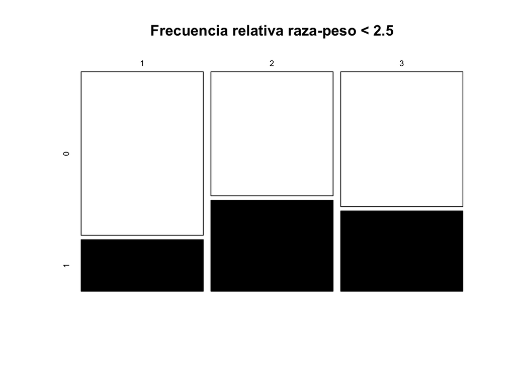

```r
plot(prop.table(table(birthwt$race, birthwt$low), margin = 1), main = "Frecuencia relativa raza-peso < 2.5", col = c("white", "black"))
```

4. Dibuja un diagrama bidimensional de barras, con las barras organizadas en bloques, que permita visualizar la información de los ejercicios anteriores. Aprovecha para poner nombres adecuados a los bloques, colores a las barras, y añadir una leyenda que explique qué representa cada barra.

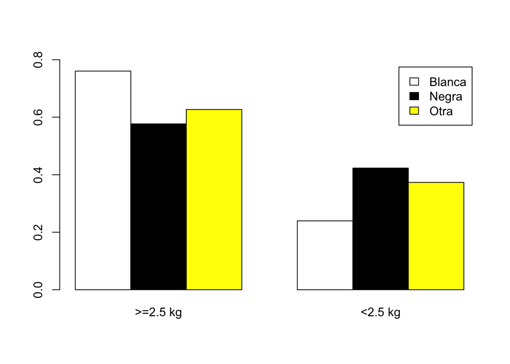

```r
barplot(prop.table(table(birthwt$race, birthwt$low), margin = 1), beside = TRUE, legend.text = c("Blanca", "Negra", "Otra"), col = c("white", "black", "yellow"), ylim = c(0, 0.8), names.arg = c(">=2.5 kg", "<2.5 kg"))
```

5. ¿Se puede obtener alguna conclusión de la tabla y el diagrama de barras anterior? Argumenta tu respuesta.

De los gráficos y tablas, se observa que hay una mayor tendencia a tener hijos que pesen menos 2.5 kg en madres de raza negra (42%) y de otra razas (37%).

6. Repite los cuatro ejercicios anteriores para los pares (madre fumadora o no, peso inferior a 2.5 kg o no) y para los pares (madre hipertensa o no, peso inferior a 2.5 kg o no.

Repetimos primero para par madre fumadora (si, no)-peso inferior a 2.5 kg (si, no).

```r
#Tabla de frecuencias relativas
prop.table(table(birthwt$smoke, birthwt$low), margin = 1)
```

```
##
##             0         1
##   0 0.7478261 0.2521739
##   1 0.5945946 0.4054054
```

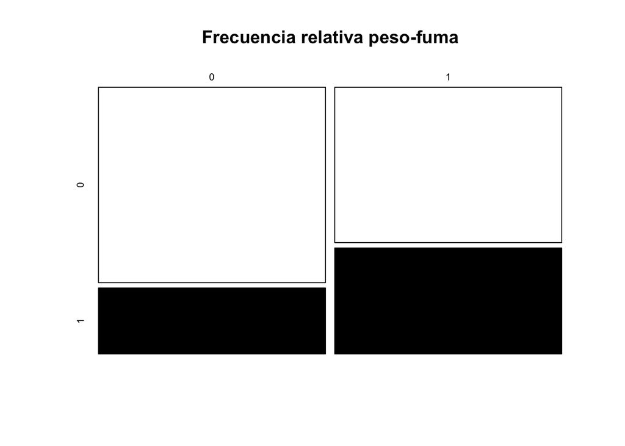

```r
#Gráfico de mosaico.
plot(prop.table(table(birthwt$smoke, birthwt$low), margin = 1), main = "Frecuencia relativa peso-fuma", col=c("white", "black"))
```

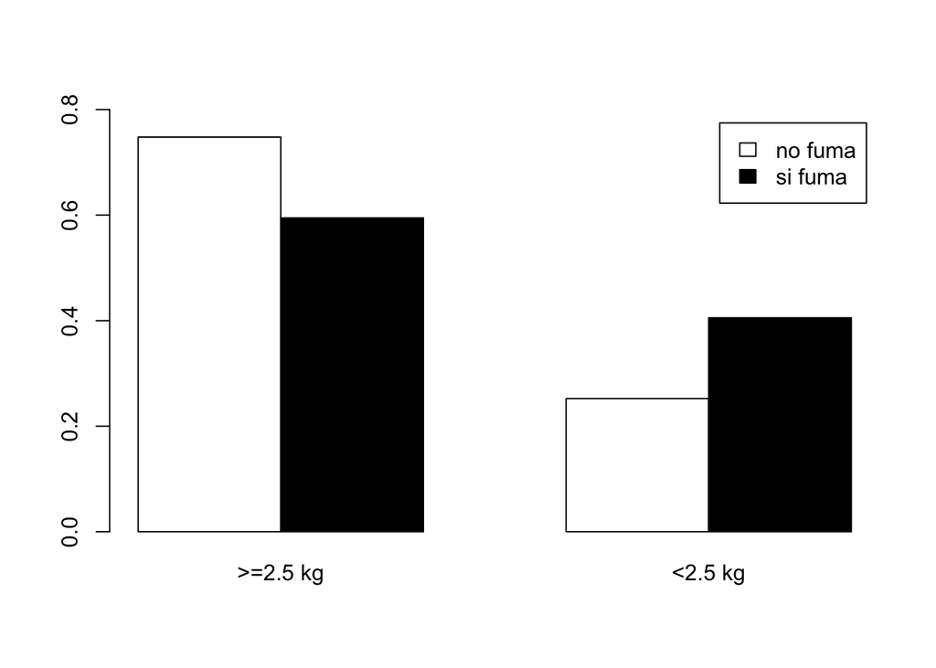

```r
#Gráfico de barras
barplot(prop.table(table(birthwt$smoke, birthwt$low), margin = 1), beside = TRUE, legend.text = c("no fuma", "si fuma"), col = c("white", "black"), ylim = c(0, 0.8), names.arg = c(">=2.5 kg", "<2.5 kg"))
```

Se observa que hay una mayor probabilidad de que el hijo pese menos de 2.5 kg en madres fumadoras (40,5% de las madres que fumaron tuvieron hijos con peso menor a 2,5 kg mientras que solo el 25,2% de las que no fumaron).

Repetimos el ejercicio para madre hipertensa (si, no)-peso inferior 2.5 kg (si, no)

```r
#Tabla de frecuencias relativas
prop.table(table(birthwt$ht, birthwt$low), margin = 1)
```

```
##
##             0         1
##   0 0.7062147 0.2937853
##   1 0.4166667 0.5833333
```

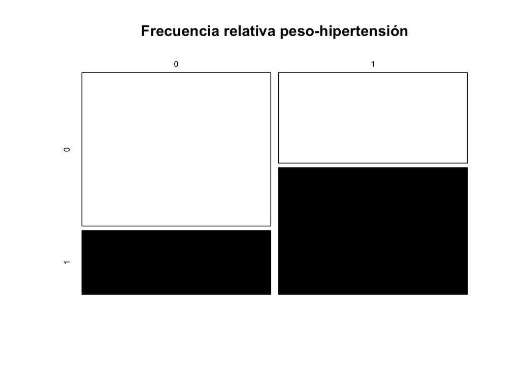

```r
#Gráfico de mosaico.
plot(prop.table(table(birthwt$ht, birthwt$low), margin = 1), main = "Frecuencia relativa peso-hipertensión", col=c("white", "black"))
```

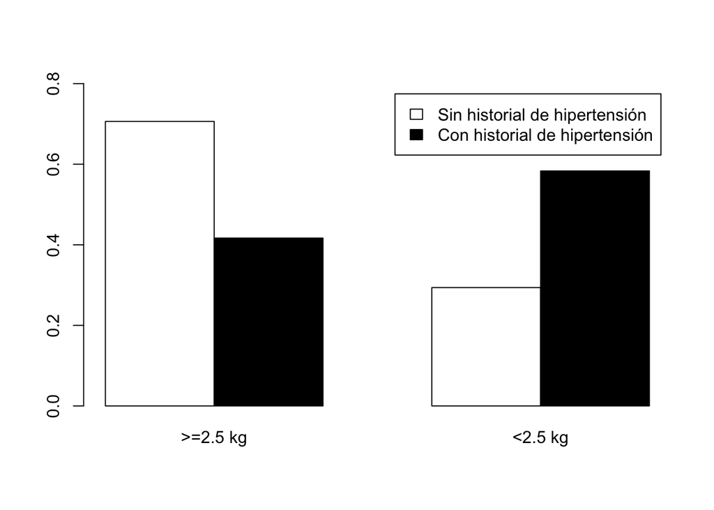

```r
#Gráfico de barras
barplot(prop.table(table(birthwt$ht, birthwt$low), margin = 1), beside = TRUE, legend.text = c("Sin historial de hipertensión", "Con historial de hipertensión"), col = c("white", "black"), ylim = c(0, 0.8), names.arg = c(">=2.5 kg", "<2.5 kg"))
```

Se observa que para madres con historial de hipertensión, hay mayor probabilidad de que el hijo pese menos de 2,5 kg al nacer (58%).

7. Calcula una tabla de frecuencias relativas marginales de las ternas (raza de la madre, madre fumadora o no, peso inferior a 2.5 kg o no) que permita ver si la raza de la madre y su condición de fumadora o no fumadora influyen en el peso del bebé.

```r
prop.table(ftable(birthwt$race, birthwt$smoke, birthwt$low, col.vars = 3), margin = 1)
```

```
##               0          1
##
## 1 0  0.90909091 0.09090909
##   1  0.63461538 0.36538462
## 2 0  0.68750000 0.31250000
##   1  0.40000000 0.60000000
## 3 0  0.63636364 0.36363636
##   1  0.58333333 0.41666667
```

Se observa que para las madres fumadoras de las 3 razas, la probabilidad de que el hijo pese menos de 2,5 kg es mayor que si no fuman, y en el caso de madres de raza negra es mas probable que el hijo pese menos de 2,5 kg si fuma (60%).

8. Dibuja un diagrama de mosaico de la tabla del ejercicio anterior.

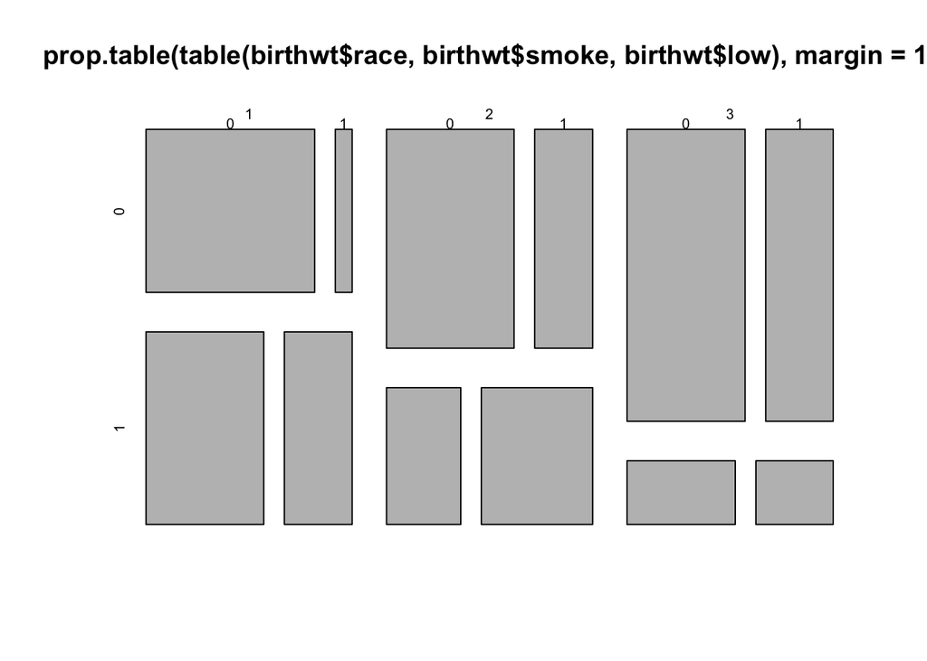

```r
plot(prop.table(table(birthwt$race, birthwt$smoke, birthwt$low), margin = 1))
```